# B2 rebound survival analysis

Fan Bu

6/9/2020

## Overview

The goal of the analysis is to study influential predictors for time to rebound. The data analyzed here are obtained in the B2 group experiments.

These potential predictors are investigated:

- **Viral load pre ART**: peak viral load, viral load at treatment & **area-under-VL-curve**
- **Antibody response**:
  - ELISA: GP41 and GP120, peak level and level at treatment
  - Neutralization: Point IC50 & POS AUC measured at 0, 2, 4, 8 weeks post ATI
- **Cell-associated RNA and DNA**:
  - SHIV RNA copies per million cell RNA: measured in blood, lymph node and rectal biopsy at 8 and 56 weeks post infection (RB only at 56 weeks)
  - SHIV DNA copies per million cell DNA: measured in blood, lymph node and rectal biopsy at 8, 16, 36 and 56 weeks post infection (no RB at 8 weeks)

Among the 10 monkeys in group B2, 9 experienced rebound (except for RQc19, labelled as “0” in the “observed” column). Below is a summary table of their rebound times (measured in days).

| ID | rebound_time | observed |
| --- | --- | --- |
| RIm19 | 17 | 1 |
| RJm19 | 35 | 1 |
| RKg19 | 18 | 1 |
| RLg19 | 12 | 1 |
| RQc19 | 98 | 0 |
| RRm19 | 24 | 1 |
| RTp19 | 7 | 1 |
| RVh19 | 18 | 1 |
| RVr19 | 28 | 1 |
| RWc19 | 14 | 1 |

Below is the basic Kaplan Meier curve of the rebound times. This curve shows the probability of surviving past any time point; that is, a point (t, p) on the curve means that a monkey has a $p \times 100\%$ chance of **not** having rebound till $t$ days.

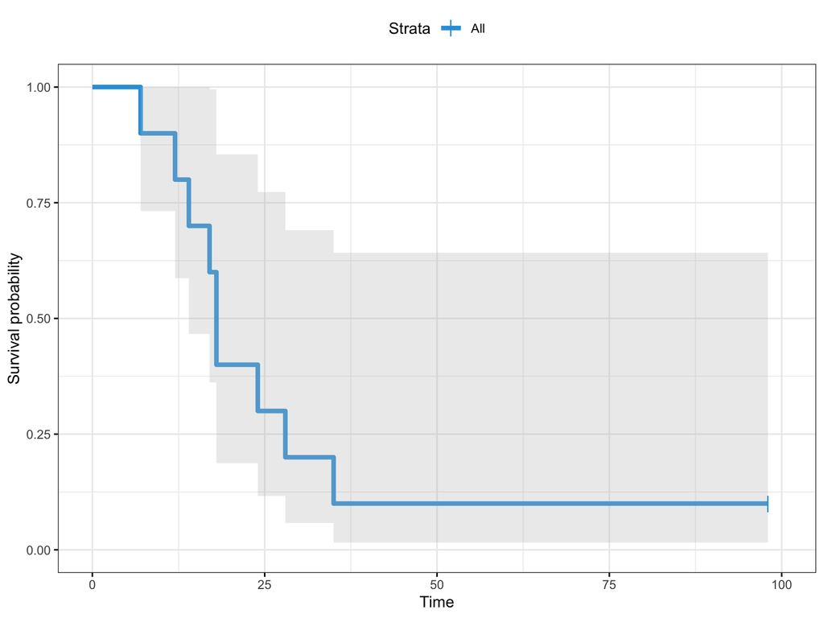

## Predictors transformations and correlations

### Predictor distributions and potential transformations

We can notice that

- all of the potential predictors are positive values, and
- most of the variables have large ranges and dispersed values

Therefore, the predictors are log-transformed.

(Moreover, we can check the “martingale residuals” to select proper functional forms for the predictors so that linearity would be satisfied for the Cox Porportional Hazards model. Some level of non-linearity is seen, and log-transformation does make the residuals seem more linear, but the small sample size doesn’t allow much certainty on this.)

Further, another representation of the “peak viral load” is created:

`peak_vl_2` = average of **top 2** viral load measurements pre ART.

This is used in the hope to compensate for possible measurement noise in the “peak” viral load.

### Correlations between predictors

Pairwise scatterplots are created to study significant correlations between potential predictors. (Basically, predictors that are hightly correlated shouldn’t be used together in a model.)

Below are the main findings:

- GP41 concentration at peak and at treatment almost perfectly correlated
- peak viral load highly correlated with GP120 at treatment and at peak
- GP120 concentration at peak and at treatment also highly correlated
- the point IC50 measurements and POS AUC values are all highly correlated, especially those measurements acquired consecutively as well as point IC50 and AUC in the same week
- viral load at treatment highly correlated with “RNA blood 8 weeks”, “RNA LN 8 weeks” and “DNA blood 8 weeks”
- peak VL highly correlated with “RNA blood 8 weeks”
- “RNA blood 8 weeks” and “RNA LN 8 weeks” highly correlated
- “DNA blood 8 weeks” and “DNA blood 16 weeks” & “DNA LN 8 weeks” and “DNA LN 36 weeks” highly correlated

## Univariate survival analysis

### Model description: Cox Porportional Hazards model

Suppose subject $i$ has covariates $Z_i$, then the hazard function ($=1-S(t)=1-Pr(\text{survive past time } t)$) for $i$ is

$$H(t;Z_i) = H_0(t) \exp(\beta^T Z_i),$$
where $H_0(t)$ is the baseline hazard function. Throughout this analysis, we use centralized (i.e, de-meaned) covariates $Z_i$.

### Non-parametric check: concordance (“C-statistic”)

Simply put, concordance is a metric of agreement between a survival model (or a predictor) and a binary survival outcome; its interpretation is very similar to that of AUC (area under the ROC curve) for binary classification.

Suppose a model assigns score function $g(Z_i)$ for a subject $i$ with covariates $Z_i$, then the concordance (also referred to as the “C-Statistic”) is defined as
$$Pr(g(Z_i) > g(Z_j) \mid T_i > T_j),$$
for any two subjects $i$ and $j$ with event time $T_i$ and $T_j$ respectively.

Of course, if we set $g$ as the identity function, then we can measure the concordance w.r.t. to the predictors themselves. Below we show the top 5 predictors with highest concordance in the dataset.

| Predictor | Concordance |
| --- | --- |
| pos_auc_0_weeks_post_ATI | 0.79545 |
| log_point_ic50_0_weekspost_ATI | 0.77273 |
| log_point_ic50_8_weekspost_ATI | 0.75000 |
| log_gp41_treat | 0.70455 |
| log_point_ic50_2_weekspost_ATI | 0.70455 |

### Model selection

To select the best univariate model, an exhaustive search is carried out by fitting a Cox PH model using each of all the potential predictors.

Then select the most promising predictor(s) by comparing AIC, as well as the p-values obtained by

- log-rank test
- Wald test
- likelihood ratio test (said to have best behavior for small sample)

At the end, the univariate model with `pos_auc_0_weeks_post_ATI` has the smallest AIC and the smallest p-value across the tests ($p=0.0024$ for LRT).

### The chosen model

`pos_auc_0_weeks_post_ATI` has a significant negative effect on the hazard function; that is, **a higher AUC at ATI delays rebound**.

```
##                           estimate     2.5 %  97.5 %
## pos_auc_0_weeks_post_ATI -17.07401 -30.76623 -3.3818
```

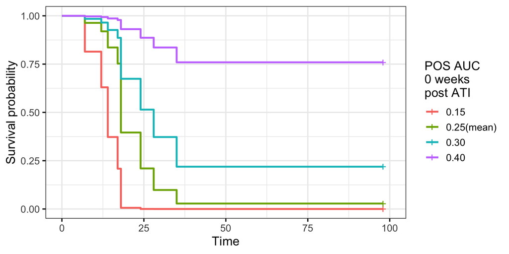

### Model validation

The following steps are conducted to validate the model/check model assumptions:

1. Testing on Schoenfeld residuals to validate “proportional hazards” assumption
   - There isn’t a clear pattern of residuals accross time, and p-value = 0.6772, which both suggest that there is no strong evidence against the PH assumption.
2. Examining deviance residuals to identify influential observations/outliers
   - Positive residual = subject died too soon
   - Negative residual = subject lived too long
   - There isn’t any residual too far from zero, suggesting that all the subjects follow similar patterns

## Bivariate survival analysis

### Model selection method

One natural way of extending the previously chosen univariate model is to find the best “addtional” predictor. Thus, an exhaustive search on the second predictor is carried out; here, we not only include linear terms but also try out a model with **an additional interaction term** of the two predictors.

As mentioned before, `pos_auc_0_weeks_post_ATI` is highly positively correlated with all the other antiboby neutralization measurements, so all the other “POS AUC” and “point IC50” variables are not included in the candidate set.

The best model is selected as the model with the smallest AIC.

(An exhaustive search among all possible bivariate models is also done as a safety measure; the resulting best model is the same.)

### The chosen bivariate model

The chosen model consists of two predictors:

- `pos_auc_0_weeks_post_ATI`
- `log_peak_vl_2` (the newly created peak viral load measure, in log-scale)
- (there is no interaction term)

To summarize: - “POS AUC” upon ATI **delays** rebound (negative effect on hazard) - peak viral load **accelerates** rebound (positive effect on hazard)

```
##                            estimate       2.5 %   97.5 %
## pos_auc_0_weeks_post_ATI -77.190540 -166.849287 12.46821
## log_peak_vl_2              5.944193   -1.521619 13.41001
```

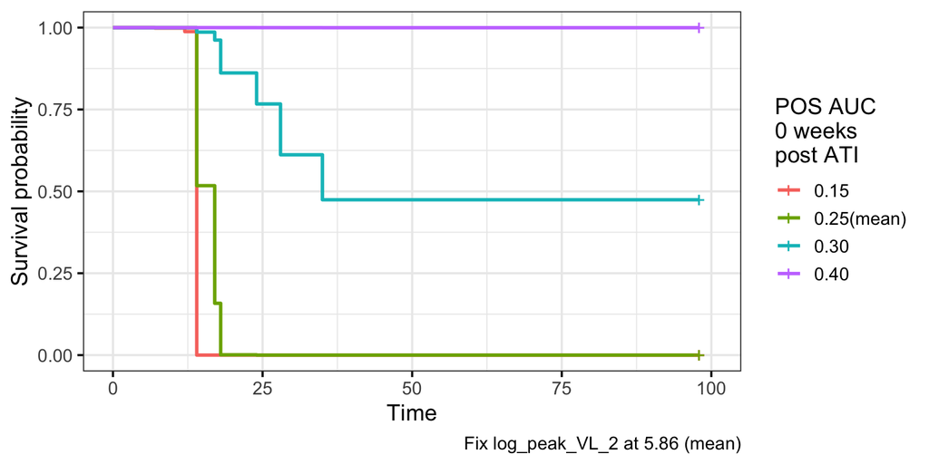

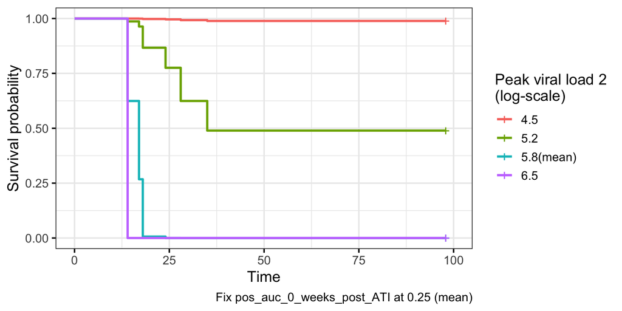

### Model validation

Same validation procedures as described above are employed to check the bivariate model. Again, there is no strong evidence against the PH assumption, and there doesn’t seem to be any outlier.

## Supplementary analysis: post ATI viral load level

Analysis is also conducted on the post ATI viral load levels to identify predictive factors. (Only analyzed data on the 9 animals with rebound.)

Two measures of “post ATI viral load level” are used (both in log10 scale):

- Peak viral load after rebound, and
- Ared-under-VL-curve after ATI

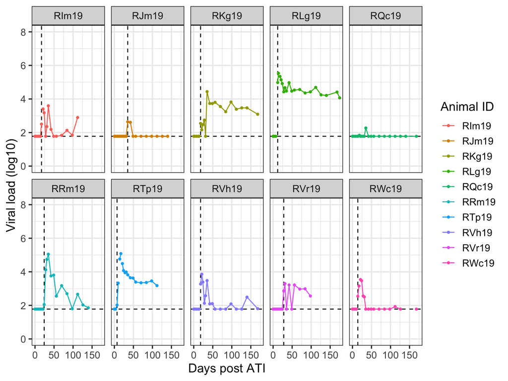

The two measures are, of course, positively correlated.

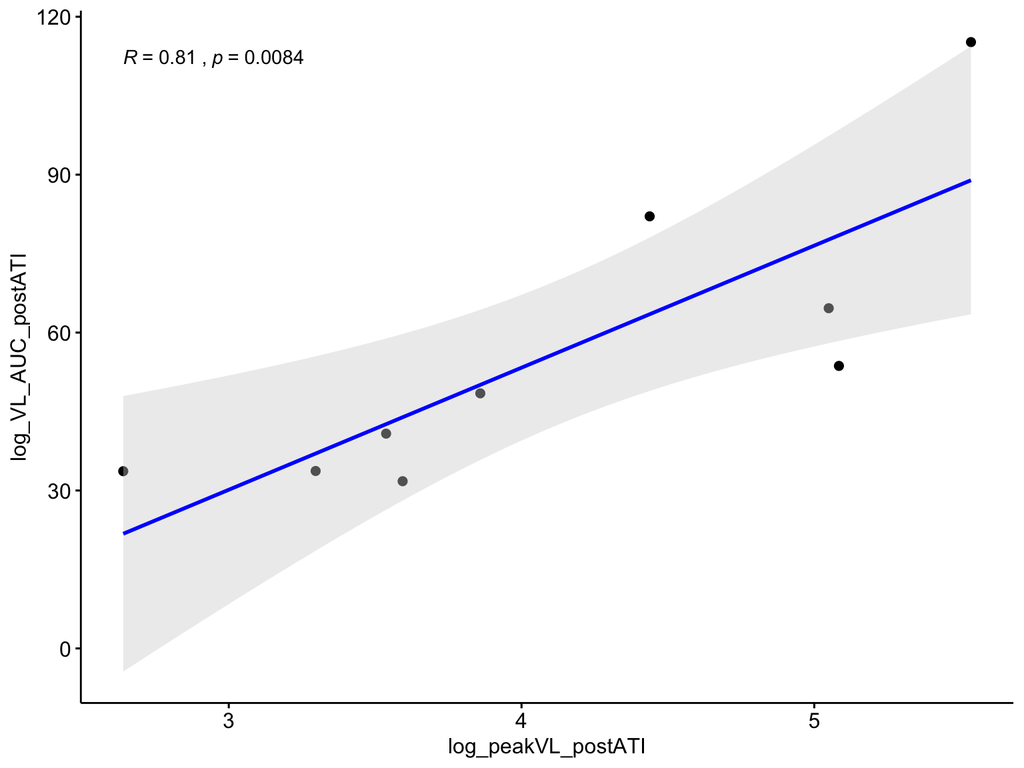

Pearson correlation coefficients are calculated between each of the viral load measures and each of the potential predictors. Predictors with very high positive correlation include:

- viral load at treatment
- cell-associated DNA/RNA level at treatment
- cell-associated DNA/RNA level during treatment

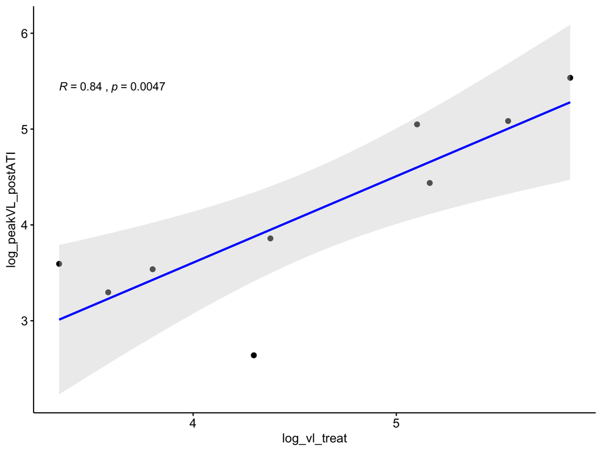

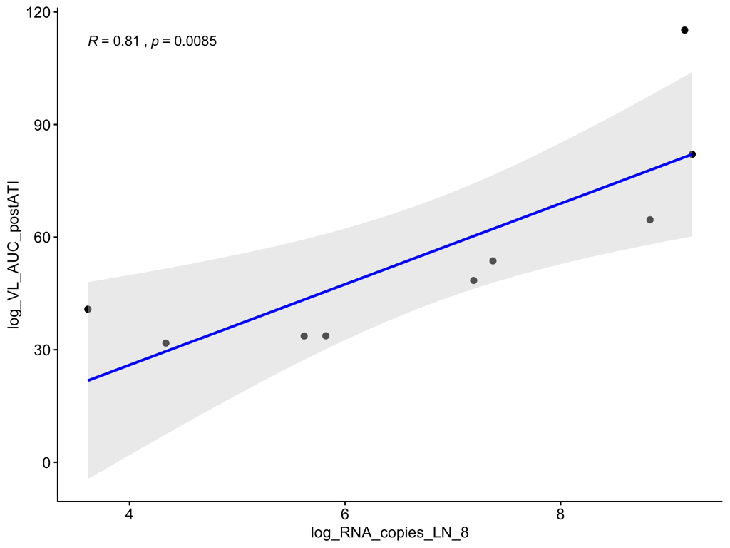

The “outlier”: animal `RLg19`, with overly high post-AIT viral load AUC.

### (TO-DO)

Some papers have suggested that CD4 cell counts are associated with post-rebound viral load level, and I plan to look at the flow cytometry next.

## Discussions

I tried to adjust for multiple testing when selecting a univariate model. Take the Likelihood Ratio Test on single predictors for example, I adopted the “Simes method (1986)”, which is said to have higher power than the Bonferroni adjustment and is capable to deal with p-values that are positively correlated.

The Sime method works like this: suppose there are $S$ hypotheses $H_i$ ($i=1,2,\ldots,S$) to test, and their **ordered** p-values are $p_{(1)}, p_{(2)}, \ldots, p_{(S)}$; then reject the joint null $H = \cap H_i$ at level $\alpha$ if at least one p-value satisfies

$$p_{(i)} < i\alpha/S.$$

Unfortunately, using this method to test the null that “none of the single predictors in the univariate Cox PH models above is significant”, the null **can’t** be rejected. So, is there really a multiple testing issue with selecting a univariate model? And if so, what should we do when the result is not what we would expect?

Below are some of my other questions: 1. Do we expect the CA-RNA and CA-DNA counts to be highly correlated? We can only see noticeable positive correlation on week 8 (post infection) measurements, but not at all for the following weeks, especially not on week 56.

2. Should we include cell counts (e.g., CD4 cell counts) as predictors (suggested by literature)? If so, need help on how to extract/use the flow data.
3. Data analysis for other experiment groups? (I’ve looked at the data tracking document and all the data folders; right now only B1 and B2 data are kind of complete.)